# molly_PeerCommentary_benap_03

Yinuo Mao

2025-02-11

> BP: Remember to include the readthedown theme formatting and table of contents + favorite pic before doing your final submission!

```r
zombies <- read.csv("zombies.csv")
```

> BP: you probably should include the actual csv in your repo (or at least a command to download it from github) just to make sure it’s there for peer commentary purposes, otherwise this will throw an error due to not finding the file on other peoples’ machines
1. Calculate the population mean and standard deviation for each quantitative random variable (height, weight, age, number of zombies killed, and years of education). NOTE: You will not want to use the built in var() and sd() commands as these are for samples.

```r
# Create a dataframe to store population statistics
pop_stats <- data.frame(Variable = c("height", "weight", "age", "zombies_killed", "years_of_education"), Mean = numeric(5), SD = numeric(5))

# Height
pop_stats$Mean[1] <- mean(zombies$height)
pop_stats$SD[1] <- sqrt(mean((zombies$height - mean(zombies$height))^2))

# Weight
pop_stats$Mean[2] <- mean(zombies$weight)
pop_stats$SD[2] <- sqrt(mean((zombies$weight - mean(zombies$weight))^2))

# Age
pop_stats$Mean[3] <- mean(zombies$age)
pop_stats$SD[3] <- sqrt(mean((zombies$age - mean(zombies$age))^2))

# Zombies Killed
pop_stats$Mean[4] <- mean(zombies$zombies_killed)
pop_stats$SD[4] <- sqrt(mean((zombies$zombies_killed - mean(zombies$zombies_killed))^2))

# Years of Education
pop_stats$Mean[5] <- mean(zombies$years_of_education)
pop_stats$SD[5] <- sqrt(mean((zombies$years_of_education - mean(zombies$years_of_education))^2))

# Display Results
pop_stats
```

```
##             Variable      Mean        SD
## 1             height  67.63010  4.307970
## 2             weight 143.90748 18.391857
## 3                age  20.04696  2.963583
## 4     zombies_killed   2.99200  1.747551
## 5 years_of_education   2.99600  1.675704
```

> BP: Love that you’re just throwing all of them into a single dataframe, really helps with legibility!
2. Use {ggplot} to make boxplots of each of these variables by gender.

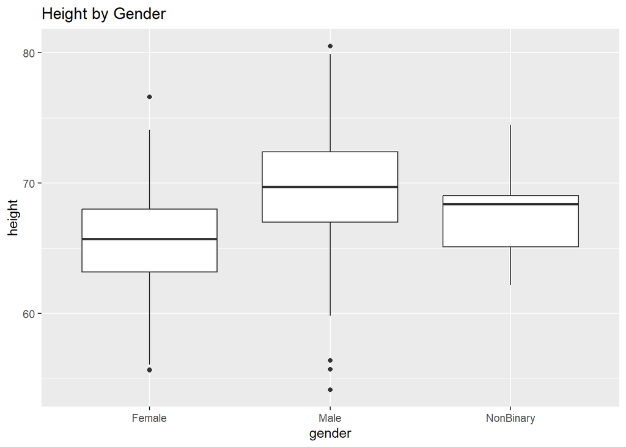

```r
library(ggplot2)
# Height by Gender
ggplot(zombies, aes(x = gender, y = height)) + geom_boxplot() + ggtitle("Height by Gender")
```

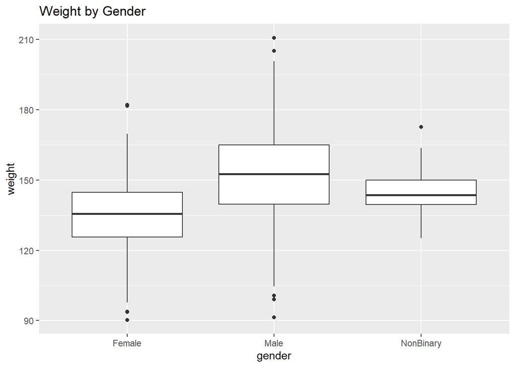

```r
# Weight by Gender
ggplot(zombies, aes(x = gender, y = weight)) + geom_boxplot() + ggtitle("Weight by Gender")
```

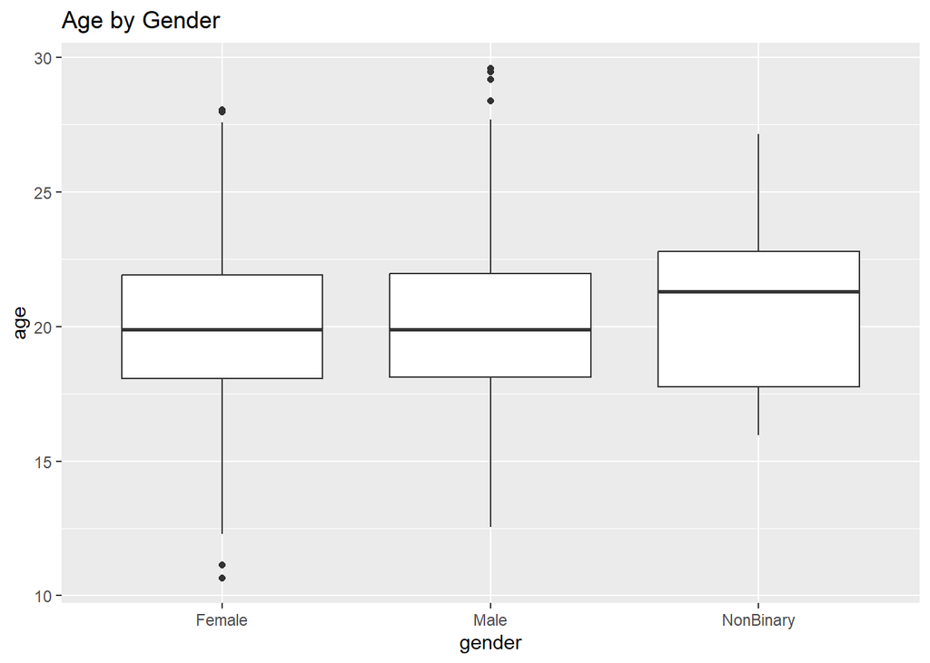

```r
# Age by Gender
ggplot(zombies, aes(x = gender, y = age)) + geom_boxplot() + ggtitle("Age by Gender")
```

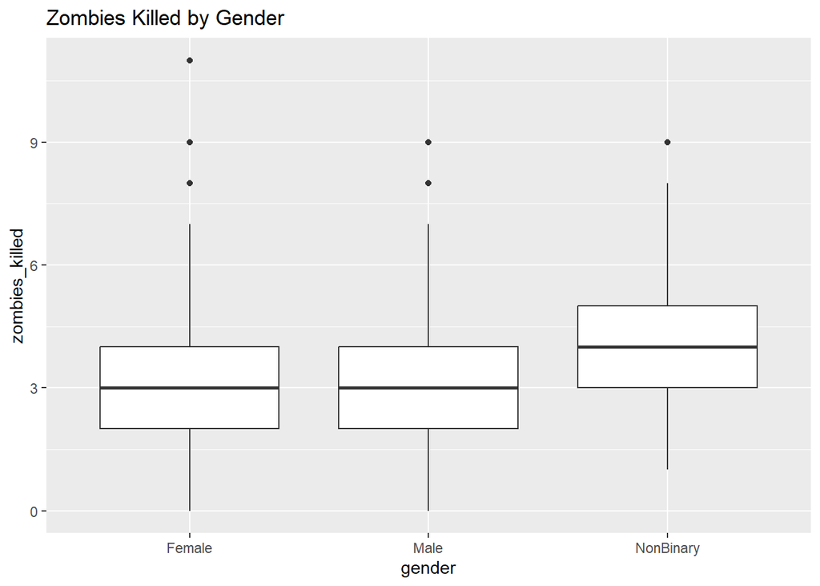

```r
# Zombies Killed by Gender
ggplot(zombies, aes(x = gender, y = zombies_killed)) + geom_boxplot() + ggtitle("Zombies Killed by Gender")
```

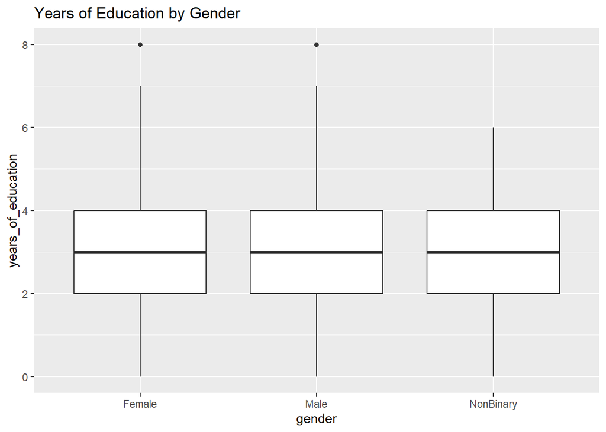

```r
# Years of Education by Gender
ggplot(zombies, aes(x = gender, y = years_of_education)) + geom_boxplot() + ggtitle("Years of Education by Gender")
```

3. Use {ggplot} to make scatterplots of height and weight in relation to age. Do these variables seem to be related? In what way?

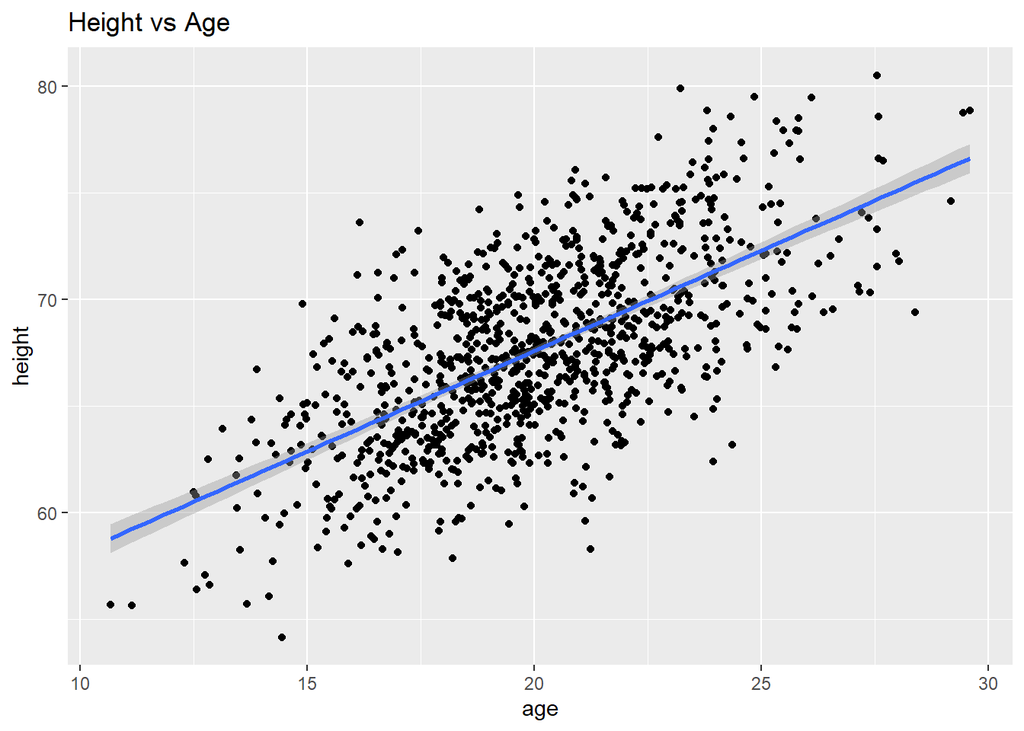

```r
# Height vs Age
ggplot(zombies, aes(x = age, y = height)) + geom_point() + geom_smooth(method = 'lm') + ggtitle("Height vs Age")
```

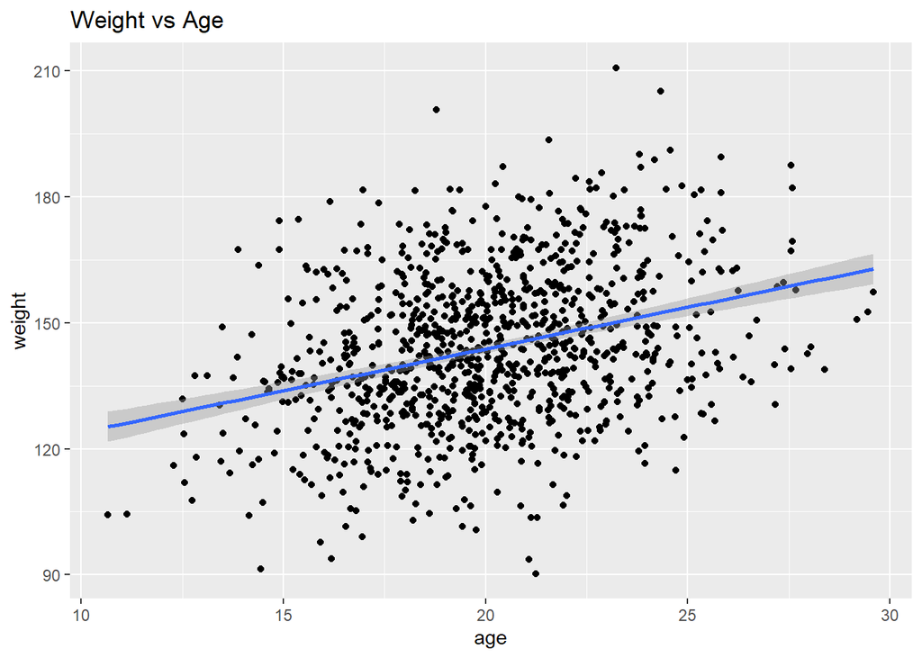

```r
# Weight vs Age
ggplot(zombies, aes(x = age, y = weight)) + geom_point() + geom_smooth(method = 'lm') + ggtitle("Weight vs Age")
```

```r
## Height and age have a stronger positive relationship than that of weight and age.
```

> BP: Looks good, but I don’t see any commentary on to what extent you think the variables are related or how?
4. Using histograms and Q-Q plots, check whether the quantitative variables seem to be drawn from a normal distribution. Which seem to be and which do not (hint: not all are drawn from the normal distribution)? For those that are not normal, can you determine from which common distribution they are drawn?

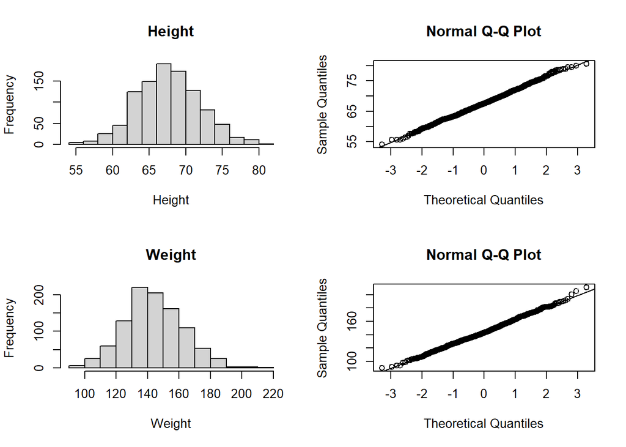

```r
par(mfrow = c(2, 2))

# Height
hist(zombies$height, main = "Height", xlab = "Height")
qqnorm(zombies$height); qqline(zombies$height)

# Weight
hist(zombies$weight, main = "Weight", xlab = "Weight")
qqnorm(zombies$weight); qqline(zombies$weight)
```

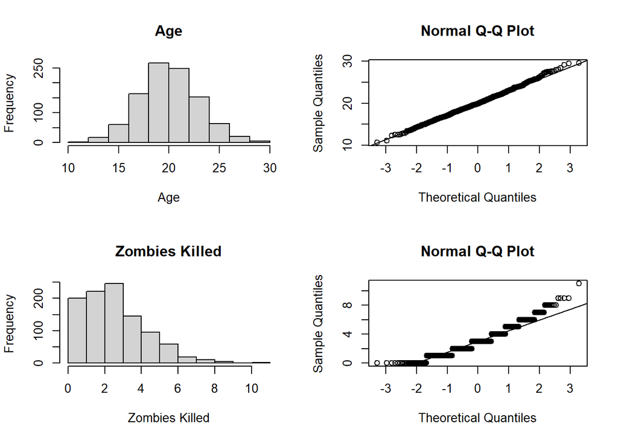

```r
# Age
hist(zombies$age, main = "Age", xlab = "Age")
qqnorm(zombies$age); qqline(zombies$age)

# Zombies Killed
hist(zombies$zombies_killed, main = "Zombies Killed", xlab = "Zombies Killed")
qqnorm(zombies$zombies_killed); qqline(zombies$zombies_killed)
```

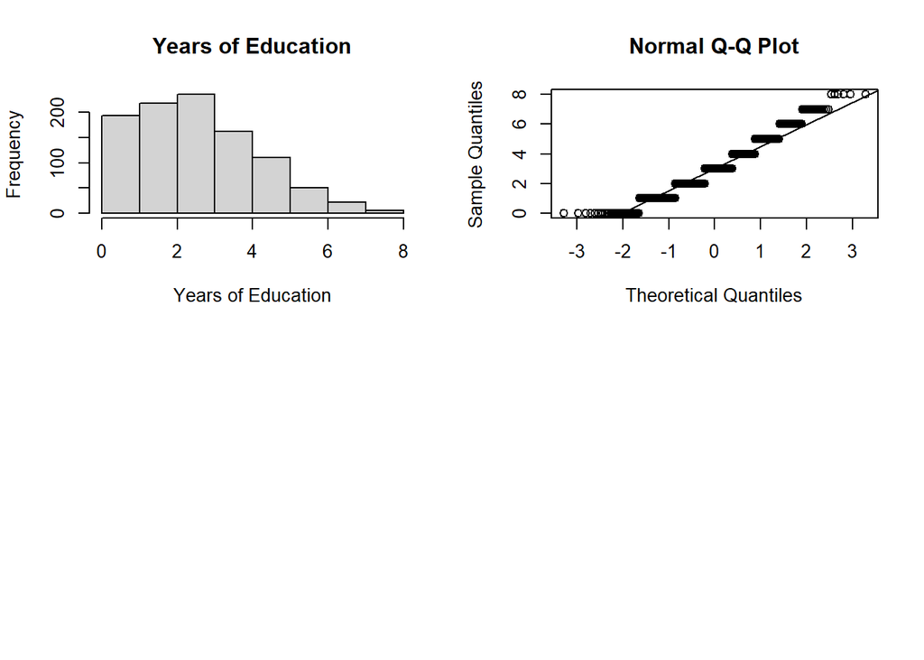

```r
# Years of Education
hist(zombies$years_of_education, main = "Years of Education", xlab = "Years of Education")
qqnorm(zombies$years_of_education); qqline(zombies$years_of_education)
par(mfrow = c(1, 1))
```

## Height: the variable is a normal distribution. The histogram is symmetric and bell-shaped, and the Q-Q plots closely align with the line. ## Weight: the variable is a normal distribution. The histogram is closely symmetric and bell-shaped, and the Q-Q plots closely align with the line. ## Age: the variable is roughly normal. The histogram is symmetric and bell-shaped, and the Q-Q plot shows minor deviations from the line. ## Zombies Killed: the variable is not normal. The histogram is right-skewed, and the Q-Q plot shows a deviation from the diagonal line. This should be the Poisson distribution. ## Years of Education: this variable is not normal. The histogram is right-skewed, and the Q-Q plot shows a strong deviation from the diagonal line. This should be the discrete distribution.

> BP: Looks good, really like that you’ve got the q-q and histograms plotted right next to each other for easy comparison. I think I’d just note that Years of Education looks like it’s another poisson distribution to me (values are discrete, distribution is cut off at zero, etc.) rather than a general discrete distribution, but I could be wrong.
5. Now use the sample() function to sample ONE subset of 30 zombie survivors (without replacement) from this population and calculate the mean and sample standard deviation for each variable. Also estimate the standard error for each variable, and construct the 95% confidence interval for each mean. Note that for the variables that are not drawn from the normal distribution, you may need to base your estimate of the CIs on slightly different code than for the normal…

```r
# Take a random sample of 30 zombie survivors
set.seed(123)
zombie_indices <- sample(1:nrow(zombies), 30, replace = FALSE)
sample_data <- zombies[zombie_indices, ]  # This line was missing

# Variables to analyze
variables <- c("height", "weight", "age", "zombies_killed", "years_of_education")

# Create a dataframe to store results
results <- data.frame(
  variable = variables,
  mean = numeric(length(variables)),
  sd = numeric(length(variables)),
  se = numeric(length(variables)),
  lower_ci = numeric(length(variables)),
  upper_ci = numeric(length(variables)))

# Calculate statistics for each variable
for (i in 1:length(variables)) {
  var_name <- variables[i]
  x <- sample_data[[var_name]]

  results$mean[i] <- mean(x)
  results$sd[i] <- sd(x)
  results$se[i] <- sd(x)/sqrt(length(x))
  t_critical <- qt(0.975, df = length(x) - 1)
  results$lower_ci[i] <- results$mean[i] - t_critical * results$se[i]
  results$upper_ci[i] <- results$mean[i] + t_critical * results$se[i]
}

# Print the results
print(results)
```

```
##             variable       mean        sd        se   lower_ci   upper_ci
## 1             height  67.639389  3.530531 0.6445838  66.321068  68.957711
## 2             weight 146.410075 14.640945 2.6730586 140.943057 151.877094
## 3                age  19.329267  2.555914 0.4666440  18.374873  20.283661
## 4     zombies_killed   2.533333  1.696514 0.3097397   1.899844   3.166822
## 5 years_of_education   3.100000  1.422722 0.2597523   2.568747   3.631253
```

6. Now draw 99 more random samples of 30 zombie apocalypse survivors, and calculate the mean for each variable for each of these samples. Together with the first sample you drew, you now have a set of 100 means for each variable (each based on 30 observations), which constitutes a sampling distribution for each variable. What are the means and standard deviations of this distribution of means for each variable? How do the standard deviations of means compare to the standard errors estimated in [5]? What do these sampling distributions look like (a graph might help here)? Are they normally distributed? What about for those variables that you concluded were not originally drawn from a normal distribution?

```r
# Set seed
set.seed(123)

# Create matrix to store 100 sample means
sample_means <- matrix(0, nrow = 100, ncol = length(variables))
colnames(sample_means) <- variables

# Draw 100 samples and calculate means
for(i in 1:100) {zombie_sample <- zombies[sample(1:nrow(zombies), 30), ]
  for(j in 1:length(variables)) {sample_means[i, j] <- mean(zombie_sample[[variables[j]]])}}

# Convert to dataframe for easier analysis
sample_means <- as.data.frame(sample_means)

# Calculate sampling distribution statistics
results <- data.frame(Varibles = variables, Mean = sapply(sample_means, mean),SD = sapply(sample_means, sd),SE = sapply(variables, function(v) sd(zombies[[v]])/sqrt(30)))

print(results)
```

```
##                              Varibles       Mean        SD        SE
## height                         height  67.694844 0.6765653 0.7869177
## weight                         weight 143.947208 2.9991708 3.3595585
## age                               age  20.072396 0.4878208 0.5413444
## zombies_killed         zombies_killed   2.958333 0.3425125 0.3192174
## years_of_education years_of_education   3.019000 0.3160238 0.3060934
```

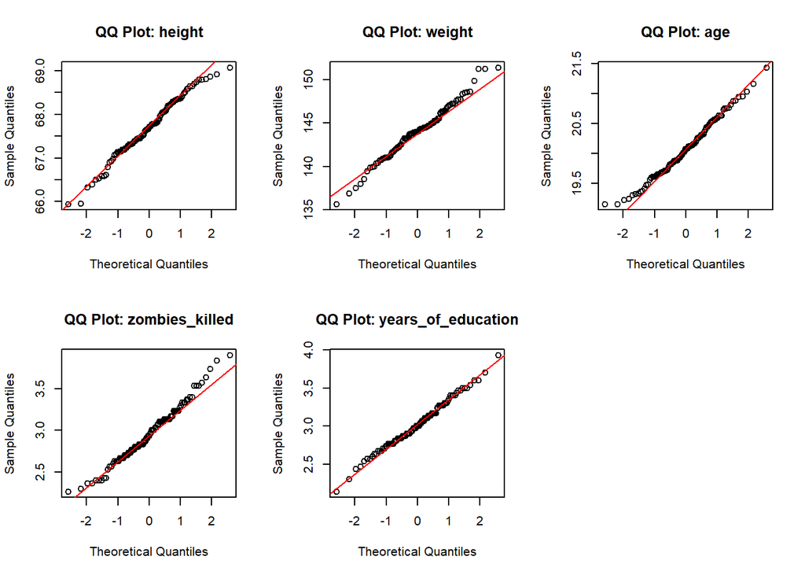

```r
# Create QQ plots
par(mfrow = c(2, 3))
for(var in variables) {qqnorm(sample_means[[var]], main = paste("QQ Plot:", var))
  qqline(sample_means[[var]], col = "red")}
```

## Comparing Standard Deviations to Standard Errors

The standard deviations of the sampling distributions should closely match the standard errors calculated in question 5. This confirms the statistical theory that the standard deviation of sample means equals σ/√n.

## Normality of Sampling Distributions

For variables that were originally normally distributed (height, weight, age), their sampling distributions is also be normal. For zombies_killed and years of education, even these non-normal variables will have approximately normal sampling distributions, the Q-Q plots show points much closer to the diagonal line and all sampling distributions will appear roughly normal. This demonstrates why we can apply many statistical tests to means even when the original data isn’t normal, as long as the sample size is large enough (n≥30).

> BP: Looks good! I think my only major feedback is just to make sure you’re following the formatting guidelines and maybe to comment your code a bit more. Especially those large chunks in questions 5 & 6, which can be kinda hard to follow maybe go into a bit more depth on what the different arguments you’re passing to each function actually do. I do appreciate the way you have it all broken up and labeled, though, really makes it easier for me to parse!